# Machine Learning Project

Robert Cordery

Monday, March 21, 2015

## Background

Using devices such as Jawbone Up, Nike FuelBand, and Fitbit it is now possible to collect a large amount of data about personal activity relatively inexpensively. In this project, the goal is to predict the quality of exercise using data from accelerometers on 6 participants. More information, and their paper is available from the website here: http://groupware.les.inf.puc-rio.br/har.

```r
# Load teh necessary libraries
library(caret)
```

```r
library(ggplot2)
library(GGally)
library(dplyr)
```

## Load data

The training data for this project are available here:

https://d396qusza40orc.cloudfront.net/predmachlearn/pml-training.csv https://d396qusza40orc.cloudfront.net/predmachlearn/pml-testing.csv

The data has several variables that are all or mostly NA or blank. I remove those from the loaded data.

```r
trainFile <- "pml-training.csv"
testFile <- "pml-testing.csv"
dataUrl <- "https://d396qusza40orc.cloudfront.net/predmachlearn"
dataLocal <- "./data"
dir.create(dataLocal, showWarnings = FALSE)

trainSource <- paste(dataLocal,trainFile, sep="/")
if(!file.exists(trainSource)){
    download.file(url = paste(dataUrl,trainFile, sep="/"),
                  destfile = trainSource, method="curl")
}
trainData <- read.csv(trainSource, na.strings=c("NA","","#DIV/0!"))
trainData$classe <- factor(trainData$classe)
trainData$user_name <- factor(trainData$user_name)
useCol <- colSums(is.na(trainData)) < 1000
trainData <- trainData[,useCol]
testSource <- paste(dataLocal,testFile, sep="/")
if(!file.exists(testSource)){
        download.file(url = paste(dataUrl,testFile, sep="/"),
                  destfile = testSource, method="curl")

}
testData <- read.csv(testSource)
testData <- testData[,useCol]
```

# Partition the data

The trainData set is quite large with a large number of variables, so I decided to split the data rows randomly into three parts:

1. an initial set of 20% of the data is used to create an initial model to identify the most important variables,
2. a larger training set of %60 of the data is used to train a random forest model,
3. the remaining 20% set is used for cross validation and to estimate the confusion matrix.

Variables that are not related to motion are removed from the data. For example, I removed the username variable. While the result may be correlated with username, the goal is to predict the quality of exercise for another person, not for the particular test subjects.

```r
initialPartition <- createDataPartition(y=trainData$classe,p=0.2, times=2,list=FALSE)
indexInit <- initialPartition[,1]
indexTest <- initialPartition[,2]
indexTrain<- setdiff(1:nrow(trainData),
                   union(indexInit,indexTest))
# Construct the initial, training and test data sets
initSet <- trainData[indexInit,8:60]
testSet <- trainData[indexTest,8:60]
trainSet<- trainData[indexTrain,8:60]
```

# Select important variables using a rough model

Here we use the initial set to select variables that meet a minimum importance level.

```r
modFit <- train(classe ~ ., data=initSet, method="rf", prox=TRUE, ntree=30, tuneGrid = NULL, tuneLength = 3)
minImportance <- 8
importanceVars <- varImp(modFit)
useVar <- importanceVars$importance > minImportance
sum(useVar)
```

```
## [1] 22
```

```r
# Add in the output variable classe
useVar=c(useVar,TRUE)
trainSet2<-trainSet[,useVar]
testSet2 <-testSet[,useVar]
```

## Train the final model

The final model is trained on the training set with the reduced set of variables. The selected variables are roll_belt, pitch_belt, yaw_belt, gyros_belt_z, accel_belt_z, magnet_belt_x, magnet_belt_y, magnet_belt_z, magnet_arm_x, roll_dumbbell, yaw_dumbbell, total_accel_dumbbell, gyros_dumbbell_y, accel_dumbbell_y, accel_dumbbell_z, magnet_dumbbell_x, magnet_dumbbell_y, magnet_dumbbell_z, roll_forearm, pitch_forearm, accel_forearm_x, magnet_forearm_z, classe.

```r
fitControl <- trainControl(method="cv" )
modFitTrain <- train(classe ~ ., trControl=fitControl, data=trainSet2, method="rf", prox=TRUE, ntree=40,tuneGrid = NULL, tuneLength = 3)
importanceVarsTrain <- varImp(modFitTrain)
```

## Cross validation

Now we use the part of the data set aside for testing the final model and construct a confusion matrix.

[output not shown]

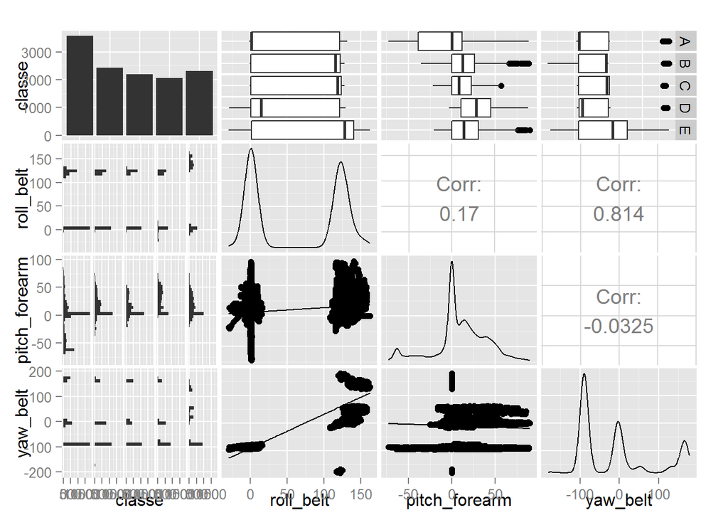

```r
predictions <- predict(modFitTrain, newdata = testSet2)

a=c("classe", "roll_belt", "pitch_forearm", "yaw_belt")


ggpairs(trainSet[,a], lower = list(continuous = "smooth"),params = c(method = "loess"))
```

```r
confusionMatrix(predictions, testSet2$classe)
```

```
## Confusion Matrix and Statistics
##
##           Reference
## Prediction    A    B    C    D    E
##          A 1112   11    0    2    0
##          B    4  740   11    1    1
##          C    0    8  672   15    0
##          D    0    1    2  624    1
##          E    0    0    0    2  720
##
## Overall Statistics
##
##                Accuracy : 0.985
##                  95% CI : (0.9807, 0.9885)
##     No Information Rate : 0.2842
##     P-Value [Acc > NIR] : < 2.2e-16
##
##                   Kappa : 0.981
##  Mcnemar's Test P-Value : NA
##
## Statistics by Class:
##
##                      Class: A Class: B Class: C Class: D Class: E
## Sensitivity            0.9964   0.9737   0.9810   0.9689   0.9972
## Specificity            0.9954   0.9946   0.9929   0.9988   0.9994
## Pos Pred Value         0.9884   0.9775   0.9669   0.9936   0.9972
## Neg Pred Value         0.9986   0.9937   0.9960   0.9939   0.9994
## Prevalence             0.2842   0.1935   0.1744   0.1640   0.1839
## Detection Rate         0.2832   0.1884   0.1711   0.1589   0.1833
## Detection Prevalence   0.2865   0.1928   0.1770   0.1599   0.1839
## Balanced Accuracy      0.9959   0.9842   0.9870   0.9839   0.9983
```

## Apply final model to the testData

The classe variable is not known for the test data set.

```r
testPredictions <- predict(modFitTrain, newdata = testData)
answers=as.character(testPredictions)
answers
```

```
##  [1] "B" "A" "B" "A" "A" "E" "D" "B" "A" "A" "B" "C" "B" "A" "E" "E" "A"
## [18] "B" "B" "B"
```

## Generate submissions

```r
pml_write_files = function(x){
  n = length(x)
  for(i in 1:n){
    filename = paste0("problem_id_",i,".txt")
    write.table(x[i],file=filename,quote=FALSE,row.names=FALSE,col.names=FALSE)
  }
}

answers=as.character(testPredictions)
pml_write_files(answers)
```

## References

Velloso, E.; Bulling, A.; Gellersen, H.; Ugulino, W.; Fuks, H. Qualitative Activity Recognition of Weight Lifting Exercises. Proceedings of 4th Augmented Human (AH) International Conference in cooperation with ACM SIGCHI (Augmented Human’13) . Stuttgart, Germany: ACM SIGCHI, 2013.